## SAVANT Project

#### **S**ystematicity **a**nd **V**ariation In Word Structure Processing Across Languages: A **N**euro-**T**ypology Approach

##### This project investigates the processing of numerals in the Azeri language. The project aimed to build on the previous research in English and to provide data-driven results to substantiate the fact that speech is decomposed into its constituents (i.e meaningful pieces) even before the brain has access to meaning.

Task items consist of a numeral + a plural or a non-plural noun. In order to examine the processing of numerals, we have made violations in the structure of items.

#### The predictor/independent factors are 7 conditions including:

1. Gramm.Simple = grammatical simple plural
2. Gramm.Num = grammatical numeral
3. SemViol = semantic violation (numeral + noun + plural suffix)
4. SynViol.Pl = syntactic violation (verb + plural suffix)
5. HarmViol = harmony violation
6. SynViol.Num = syntactic violation numeral (numeral + verb)
7. GramHarm = grammatical harmony (8. FillerGram = filler grammatical)

And the response/dependent factors are lexical decision accuracy and reaction time. There are 24 items per condition. Therefore, 72 grammatical items and 96 ungrammatical items. In order to make the task balanced, we added 24 grammatical fillers similar to grammatical numeral items.

Also, there are additional participant variables that might account for the variance in reaction time and accuracy: 1. language dominance 2. self-assessed proficiency 3. participant age 4. education

##### fixed effects: 1. Condition

##### random effects: 1. Participants, 2. Items

Loading libraries

```r
library(lme4)
library(glmm)
library(tidyverse)
```

```r
library(ggplot2)
library(afex)
library(trimr)
require(car)
require(lattice)
require(itsadug)
library(languageR)
library(plotrix)
library(Hmisc)
library(rlist)
library(effects)
library(sjPlot)
library(effectsize)
library(trimr)
library(palmerpenguins)
library(taylor)
library(emmeans)
library(ggsignif)
```

Loading the raw dataset

```r
SAVANT1 = read.csv(file = "140886-v1-7vyf.csv",  header = T)
SAVANT2 = read.csv(file = "140886-v1-p745.csv", header = T)
SAVANT3 = read.csv(file = "140362-v25-p745.csv", header = T)
SAVANT4 = read.csv(file = "140362-v25-7vyf.csv", header = T)
SAVANT5 = read.csv(file = "140886-v2-7vyf.csv", header = T)
SAVANT6 = read.csv(file = "140886-v2-p745.csv", header = T)
```

Combining data

```r
SAVANT = rbind(SAVANT1, SAVANT2, SAVANT3, SAVANT4, SAVANT5, SAVANT6)
```

```r
colnames(SAVANT)
```

```
##  [1] "Event.Index"                     "UTC.Timestamp"
##  [3] "UTC.Date.and.Time"               "Local.Timestamp"
##  [5] "Local.Timezone"                  "Local.Date.and.Time"
##  [7] "Experiment.ID"                   "Experiment.Version"
##  [9] "Tree.Node.Key"                   "Repeat.Key"
## [11] "Schedule.ID"                     "Participant.Public.ID"
## [13] "Participant.Private.ID"          "Participant.Starting.Group"
## [15] "Participant.Status"              "Participant.Completion.Code"
## [17] "Participant.External.Session.ID" "Participant.Device.Type"
## [19] "Participant.Device"              "Participant.OS"
## [21] "Participant.Browser"             "Participant.Monitor.Size"
## [23] "Participant.Viewport.Size"       "Checkpoint"
## [25] "Room.ID"                         "Room.Order"
## [27] "Task.Name"                       "Task.Version"
## [29] "counterbalance.nnh1"             "counterbalance.yw81"
```

[output cut: 18 more lines]

Keeping necessary columns

```r
cols_to_keep <- c("Participant.Private.ID",
  "Reaction.Time",
  "Participant.Status",
  "Participant.Completion.Code",
  "Participant.Device.Type",
  "Trial.Number",
  "Response.Type",
  "Response",
  "Correct",
  "Display",
  "Component.Name",
  "Spreadsheet..condition",
  "Spreadsheet..answer",
  "Spreadsheet..item",
  "Spreadsheet..trial",
  "Spreadsheet..Freq",
  "Spreadsheet..set",
  "Object.ID",
  "Response.Type"
)
```

```r
SAVANT_Data <- select(SAVANT, all_of(cols_to_keep)
)
```

```r
n_distinct(SAVANT_Data$Participant.Private.ID)
```

```
## [1] 84
```

There are 84 participants.

```r
unique(SAVANT_Data$Participant.Private.ID)
```

```
##  [1] 9233109 9234466 9237013 9240504 9241138 9243037 9255695 9266541 9267518
## [10] 9267703 9282211 9284773 9296372 9302145 9308196 9340633 9341704 9341945
## [19] 9344867 9345197 9353510 9377034 9391632 9391791 9393357 9394993 9395027
## [28] 9396974 9401799 9404969 9405294 9406319 9410461 9431250 9232862 9239266
## [37] 9283613 9393588 9393177 9376385 9405075 9347028 9345406 9343579 9342048
## [46] 9341830 9340556 9340554 9301932 9295713 9287678 9266761 9265938 9263836
## [55] 9245982 9241336 9237613 9234672 9393806 9395012 9397582 9399009 9410457
## [64] 9309253 9458745 9481489 9217237 9217896 9217946 9221735 9224874 9239415
## [73] 9216758 9217683 9217967 9221421 9233675 9233740 9506472 9508509 9710186
## [82] 9505769 9677314 9709165
```

```r
view(SAVANT_Data)
```

Loading Questionnaires

```r
questionnaire1 <- read.csv("140886-v1-questionnaire-e274.csv")
questionnaire2 <- read.csv("140362-v25-questionnaire-e274.csv")
questionnaire3 <- read.csv("140886-v2-questionnaire-e274.csv")
```

Combining questionnaires

```r
questionnaire <- rbind(questionnaire1,questionnaire2,questionnaire3)
```

```r
unique(questionnaire$Participant.Private.ID)
```

```
##  [1] 9232862 9233109 9234466 9234672 9237013 9237613 9239266 9240504 9241138
## [10] 9241336 9243037 9245982 9255695 9263836 9265938 9266541 9266761 9267518
## [19] 9267703 9282211 9283613 9284773 9287678 9295713 9296372 9301932 9302145
## [28] 9308196 9309253 9340556 9340554 9340633 9341704 9341830 9341945 9342048
## [37] 9343579 9344867 9345197 9345406 9347028 9353510 9376385 9377034 9391632
## [46] 9391791 9393177 9393357 9393588 9393806 9394993 9395027 9395012 9396974
## [55] 9397582 9399009 9401799 9404969 9405075 9405294 9406319 9410457 9410461
## [64] 9431250 9458745 9481489 9216758 9217237 9217683 9217896 9217946 9217967
## [73] 9221421 9221735 9224874 9233675 9233740 9239415 9505769 9506472 9508509
## [82] 9677314 9709165 9710186
```

```r
colnames(questionnaire)
```

```
##  [1] "Event.Index"                     "UTC.Timestamp"
##  [3] "UTC.Date.and.Time"               "Local.Timestamp"
##  [5] "Local.Timezone"                  "Local.Date.and.Time"
##  [7] "Experiment.ID"                   "Experiment.Version"
##  [9] "Tree.Node.Key"                   "Repeat.Key"
## [11] "Schedule.ID"                     "Participant.Public.ID"
## [13] "Participant.Private.ID"          "Participant.Starting.Group"
## [15] "Participant.Status"              "Participant.Completion.Code"
## [17] "Participant.External.Session.ID" "Participant.Device.Type"
## [19] "Participant.Device"              "Participant.OS"
## [21] "Participant.Browser"             "Participant.Monitor.Size"
## [23] "Participant.Viewport.Size"       "Checkpoint"
## [25] "Room.ID"                         "Room.Order"
## [27] "Task.Name"                       "Task.Version"
## [29] "counterbalance.nnh1"             "counterbalance.yw81"
## [31] "randomiser.rl3q"                 "counterbalance.oqb7"
## [33] "counterbalance.3hrr"             "Page"
## [35] "Page.ID"                         "Page.Counter"
## [37] "Question"                        "Response.Type"
## [39] "Key"                             "Response"
## [41] "Tag"                             "OptionOrder"
## [43] "Object.Name"                     "Object.Number"
## [45] "Object.ID"
```

Keeping necessary columns

```r
cols_to_keep <- c("Participant.Private.ID",
                  "Participant.Status",
                  "Participant.Device.Type",
                  "Question",
                  "Response",
                  "Object.ID",
                  "Key"
)

Questionnaire <- select(questionnaire, all_of(cols_to_keep))
```

```r
n_distinct(Questionnaire$Participant.Private.ID)
```

```
## [1] 84
```

```r
view(Questionnaire)
```

Looking at timedouts We don’t need to remove timedouts because they have already been labelled as “screen” in the object.ID column instead of object number, therefore they will be removed when filtering for object number.

```r
SAVANT_Timedouts <- SAVANT_Data %>% filter(Response.Type == "timedOut")
```

Checking whether participants have used mobile phones and if so I need to exclude them from data. Device type in task data:

```r
table(SAVANT_Data$Participant.Private.ID,SAVANT_Data$Participant.Device.Type)
```

```
##
##           computer mobile
##   9216758      832      0
##   9217237      832      0
##   9217683      832      0
##   9217896      832      0
##   9217946      832      0
##   9217967      832      0
##   9221421      832      0
##   9221735      832      0
##   9224874      832      0
##   9232862      832      0
##   9233109      832      0
##   9233675      832      0
##   9233740      832      0
```

[output cut: 71 more lines]

Device type in questionnaire:

```r
table(Questionnaire$Participant.Private.ID,Questionnaire$Participant.Device.Type)
```

```
##
##           computer mobile
##   9216758       77      0
##   9217237       77      0
##   9217683       77      0
##   9217896       77      0
##   9217946       77      0
##   9217967       77      0
##   9221421       77      0
##   9221735       77      0
##   9224874       78      0
##   9232862       77      0
##   9233109       77      0
##   9233675       77      0
##   9233740       77      0
```

[output cut: 71 more lines]

1 participant has used a mobile phone.

```r
colnames(SAVANT_Data)
```

```
##  [1] "Participant.Private.ID"      "Reaction.Time"
##  [3] "Participant.Status"          "Participant.Completion.Code"
##  [5] "Participant.Device.Type"     "Trial.Number"
##  [7] "Response.Type"               "Response"
##  [9] "Correct"                     "Display"
## [11] "Component.Name"              "Spreadsheet..condition"
## [13] "Spreadsheet..answer"         "Spreadsheet..item"
## [15] "Spreadsheet..trial"          "Spreadsheet..Freq"
## [17] "Spreadsheet..set"            "Object.ID"
```

```r
colnames(Questionnaire)
```

```
## [1] "Participant.Private.ID"  "Participant.Status"
## [3] "Participant.Device.Type" "Question"
## [5] "Response"                "Object.ID"
## [7] "Key"
```

Renaming columns

```r
SAVANT_Data <- SAVANT_Data %>%
  rename(
  Participant = Participant.Private.ID,
  Completion.Code= Participant.Completion.Code,
  Device.Type = Participant.Device.Type,
  RT = Reaction.Time,
  Accuracy = Correct,
  Condition = Spreadsheet..condition,
  Answer = Spreadsheet..answer,
  Item = Spreadsheet..item,
  Trial = Spreadsheet..trial,
  Freq = Spreadsheet..Freq,
  Set = Spreadsheet..set,
  Object = Object.ID
  )
```

```r
Questionnaire <- Questionnaire %>%
  rename(
  Participant = Participant.Private.ID,
  Device.Type = Participant.Device.Type,
  Object = Object.ID
)
```

looking at age range

```r
Age <- Questionnaire %>%
  filter(Object == "object-13") %>%
  distinct(Participant, Response)
```

Some participants have entered their age in Persian. I will change them into English in questionnaire.

```r
Questionnaire <- Questionnaire %>%
  mutate( Response = str_replace_all(Response, "۴۲","42"))

Questionnaire <- Questionnaire %>%
  mutate( Response = str_replace_all(Response, "36 سال",
                                       "36"))
```

```r
Age <- Questionnaire %>%
  filter(Object == "object-13") %>%
  distinct(Participant, Response)
```

Participant 9287678 is under the age of 18 and needs to be excluded.

Mean age of participants changing age to a numeric value and calculating mean

```r
age_numeric <- as.numeric(Age$Response)
str(age_numeric)
```

```
##  num [1:84] 30 30 36 47 36 28 42 32 30 22 ...
```

```r
mean(age_numeric)
```

```
## [1] 34.07143
```

```r
range(age_numeric)
```

```
## [1] 16 59
```

Where were participants born?

```r
Place_of_Birth <- Questionnaire %>%
  filter(Object == "object-15") %>%
  distinct(Participant, Response)
```

Questions in questionnaire include self-assessed language proficiency and language use and responses are under Response column labelled under Object column, for instance the response related to the speaking skill in Azeri is incorporated in the Object-40 row.

Object-40: Language use- Speaking in Azeri Object-76: Language use- Listening in Azeri Object-77: Language use- Writing in Azeri Object-82: Language use- Reading in Azeri Object-86: Self-proficiency in speaking in Azeri Object-88: Self-proficiency in listening in Azeri Object-89: Self-proficiency in reading in Azeri Object-92: Self-proficiency in writing in Azeri Object-41: Language use- Speaking in Persian Object-78: Language use- Listening in Persian Object-80: Language use- Writing in Persian Object-83: Language use- Reading in Persian

```r
str(Questionnaire)
```

```
## 'data.frame':    6483 obs. of  7 variables:
##  $ Participant       : int  9232862 9232862 9232862 9232862 9232862 9232862 9232862 9232862 9232862 9232862 ...
##  $ Participant.Status: chr  "complete" "complete" "complete" "complete" ...
##  $ Device.Type       : chr  "computer" "computer" "computer" "computer" ...
##  $ Question          : chr  "" "<p style=\"text-align: right;\"> جنسیت شما چیست؟</p>  " "<p style=\"text-align: right;\"> جنسیت شما چیست؟</p>  " "<p style=\"text-align: right;\"> کدام شهر/روستا به دنیا آمدید؟</p>  " ...
##  $ Response          : chr  "BEGIN" "زن" "1" "زنجان" ...
##  $ Object            : chr  "" "object-117" "object-117" "object-15" ...
##  $ Key               : chr  "" "value" "quantised" "value" ...
```

Converting characters to numeric in the response column

```r
Questionnaire <- Questionnaire %>% mutate(
  Response = as.numeric(Response)
)
str(Questionnaire)
```

```
## 'data.frame':    6483 obs. of  7 variables:
##  $ Participant       : int  9232862 9232862 9232862 9232862 9232862 9232862 9232862 9232862 9232862 9232862 ...
##  $ Participant.Status: chr  "complete" "complete" "complete" "complete" ...
##  $ Device.Type       : chr  "computer" "computer" "computer" "computer" ...
##  $ Question          : chr  "" "<p style=\"text-align: right;\"> جنسیت شما چیست؟</p>  " "<p style=\"text-align: right;\"> جنسیت شما چیست؟</p>  " "<p style=\"text-align: right;\"> کدام شهر/روستا به دنیا آمدید؟</p>  " ...
##  $ Response          : num  NA NA 1 NA 0 0 1 0 NA NA ...
##  $ Object            : chr  "" "object-117" "object-117" "object-15" ...
##  $ Key               : chr  "" "value" "quantised" "value" ...
```

To calculate the mean for self-assessed proficiency in speaking I need to filter for object-86:

```r
Prof_Speak <- Questionnaire %>% filter(Object == "object-86")
```

2 participants have rated their proficiency in speaking as bad as 1.

Mean of self-assessed proficiency in speaking

```r
Mean_Prof_Speak <- Prof_Speak %>%
  summarise(Mean_Speaking = mean(as.numeric(Response))/7*100
)
Mean_Prof_Speak
```

```
##   Mean_Speaking
## 1      79.08163
```

Mean of self-assessed proficiency in listening in Azeri

```r
Prof_Listen <- Questionnaire %>%
  filter(Object == "object-88")

Mean_Prof_Listen <- Prof_Listen %>%
  summarise(Mean_Listening = mean(as.numeric(Response))/7*100
)
Mean_Prof_Listen
```

```
##   Mean_Listening
## 1       80.95238
```

Mean of self-assessed proficiency in reading in Azeri

```r
Prof_Read <- Questionnaire %>%
  filter(Object == "object-89")

Mean_Prof_Read <- Prof_Read %>%
  summarise(Mean_Reading=mean(as.numeric(Response))/7*100
)
Mean_Prof_Read
```

```
##   Mean_Reading
## 1      54.2517
```

Mean of self-assessed proficiency in writing in Azeri

```r
Prof_Write <- Questionnaire %>%
  filter(Object == "object-92")

Mean_Prof_Write <- Prof_Write %>%
  summarise(Mean_Writing=mean(as.numeric(Response))/7*100
)
Mean_Prof_Write
```

```
##   Mean_Writing
## 1     41.32653
```

Mean of self-assessed proficiency in four skills in Azeri per participant

```r
Self_Assess_Prof <- Questionnaire %>%
  filter(Object =="object-86"|Object == "object-88"|Object == "object-89"|Object == "object-92"
)

Mean_Prof <- Self_Assess_Prof %>%
  group_by(Participant) %>%
  summarise(Mean_Proficiency=mean(as.numeric(Response))/7*100) %>%
  arrange(Mean_Proficiency)

Mean_Prof
```

```
## # A tibble: 84 × 2
##    Participant Mean_Proficiency
##          <int>            <dbl>
##  1     9217967             28.6
##  2     9405075             28.6
##  3     9267518             32.1
##  4     9243037             35.7
##  5     9217896             39.3
##  6     9287678             39.3
##  7     9506472             42.9
##  8     9431250             46.4
##  9     9267703             50
## 10     9308196             50
## # ℹ 74 more rows
```

Merging mean of proficiency to the data

```r
SAVANT_Data <- merge(Mean_Prof,SAVANT_Data, by=c("Participant")
)
```

```r
n_distinct(SAVANT_Data$Participant)
```

```
## [1] 84
```

```r
unique(SAVANT_Data$Participant)
```

```
##  [1] 9216758 9217237 9217683 9217896 9217946 9217967 9221421 9221735 9224874
## [10] 9232862 9233109 9233675 9233740 9234466 9234672 9237013 9237613 9239266
## [19] 9239415 9240504 9241138 9241336 9243037 9245982 9255695 9263836 9265938
## [28] 9266541 9266761 9267518 9267703 9282211 9283613 9284773 9287678 9295713
## [37] 9296372 9301932 9302145 9308196 9309253 9340554 9340556 9340633 9341704
## [46] 9341830 9341945 9342048 9343579 9344867 9345197 9345406 9347028 9353510
## [55] 9376385 9377034 9391632 9391791 9393177 9393357 9393588 9393806 9394993
## [64] 9395012 9395027 9396974 9397582 9399009 9401799 9404969 9405075 9405294
## [73] 9406319 9410457 9410461 9431250 9458745 9481489 9505769 9506472 9508509
## [82] 9677314 9709165 9710186
```

Language use in Azeri: Data was filtered for language use in four skills of speaking, listening, reading and writing in Azeri

```r
Lan_Use <- Questionnaire %>%
  filter(Object =="object-40"|Object == "object-76"|Object == "object-77"|Object == "object-82"
)
```

Mean of language use in four skills by participant

```r
Mean_LanUse <- Lan_Use %>%
  group_by(Participant) %>%
  summarise(Mean_LanUse=mean(as.numeric(Response))
  ) %>%
  arrange(Mean_LanUse)
Mean_LanUse
```

```
## # A tibble: 84 × 2
##    Participant Mean_LanUse
##          <int>       <dbl>
##  1     9232862         2.5
##  2     9287678         2.5
##  3     9394993         2.5
##  4     9458745         2.5
##  5     9267518         5
##  6     9241138         7.5
##  7     9217967        10
##  8     9295713        10
##  9     9233740        12.5
## 10     9376385        12.5
## # ℹ 74 more rows
```

Merging language use mean rates to the data

```r
SAVANT_Data <- merge(Mean_LanUse, SAVANT_Data, by=c("Participant")
)
```

Mean of language use in speaking in Azeri

```r
LanUse_Speak <- Questionnaire %>%
  filter(Object =="object-40")

Mean_Use_Speak <- LanUse_Speak %>%
  summarise(Mean_Speaking=mean(as.numeric(Response))
)
Mean_Use_Speak
```

```
##   Mean_Speaking
## 1      75.83333
```

Mean of language use in listening in Azeri

```r
LanUse_Listen <- Questionnaire %>%
  filter(Object == "object-76")

Mean_Use_Listen <- LanUse_Listen %>%
  summarise(Mean_Listening=mean(as.numeric(Response))
)
Mean_Use_Listen
```

```
##   Mean_Listening
## 1       17.38095
```

Mean of language use in writing in Azeri

```r
LanUse_Write <- Questionnaire %>%
  filter(Object == "object-77")

Mean_Use_Write <- LanUse_Write %>%
  summarise(Mean_Writing=mean(as.numeric(Response))
)
Mean_Use_Write
```

```
##   Mean_Writing
## 1     11.19048
```

Mean of language use in reading in Azeri

```r
LanUse_Read <- Questionnaire %>%
  filter(Object == "object-82")

Mean_Use_Read <- LanUse_Read %>%
  summarise(Mean_Reading=mean(as.numeric(Response))
)
Mean_Use_Read
```

```
##   Mean_Reading
## 1     8.095238
```

Mean of language use in speaking in Persian

```r
LanUse_Fa_Speak <- Questionnaire %>%
  filter(Object == "object-41")

Mean_Use_Fa_Speak <- LanUse_Fa_Speak %>%
  summarise(Mean_Fa_Speak=mean(as.numeric(Response))
)
Mean_Use_Fa_Speak
```

```
##   Mean_Fa_Speak
## 1      36.42857
```

Mean of language use in listening in Persian

```r
LanUse_Fa_Listen <- Questionnaire %>% filter(Object == "object-78")

Mean_Use_Fa_Listen <- LanUse_Fa_Listen %>% summarise(Mean_Fa_Listen=mean(as.numeric(Response))
)
Mean_Use_Fa_Listen
```

```
##   Mean_Fa_Listen
## 1       63.92857
```

Mean of language use in writing in Persian

```r
LanUse_Fa_Write <- Questionnaire %>%
  filter(Object == "object-80")

Mean_Use_Fa_Write <- LanUse_Fa_Write %>%
  summarise(Mean_Fa_Write=mean(as.numeric(Response))
)
Mean_Use_Fa_Write
```

```
##   Mean_Fa_Write
## 1            85
```

Mean of language use in reading in Persian

```r
LanUse_Fa_Read <- Questionnaire %>%
  filter(Object == "object-83")

Mean_Use_Fa_Read <- LanUse_Fa_Read %>%
  summarise(Mean_Fa_Read=mean(as.numeric(Response))
)
Mean_Use_Fa_Read
```

```
##   Mean_Fa_Read
## 1     88.21429
```

Mean of language use in four skills in Persian by participant

```r
Lan_Use_Persian <- Questionnaire %>%
  filter(Object =="object-41"|Object == "object-78"|Object == "object-80"|Object == "object-83"
)
```

```r
Mean_LanUse_Persian <- Lan_Use_Persian %>%
  group_by(Participant) %>%
  summarise(Mean_LanUse_Persian=mean(as.numeric(Response))
  ) %>%
  arrange(Mean_LanUse_Persian)
Mean_LanUse_Persian
```

```
## # A tibble: 84 × 2
##    Participant Mean_LanUse_Persian
##          <int>               <dbl>
##  1     9341830                12.5
##  2     9340554                22.5
##  3     9393177                30
##  4     9394993                32.5
##  5     9241336                35
##  6     9431250                37.5
##  7     9345197                42.5
##  8     9283613                47.5
##  9     9393588                47.5
## 10     9401799                47.5
## # ℹ 74 more rows
```

Merging language use mean rates in Persian to the data

```r
SAVANT_Data <- merge(Mean_LanUse_Persian, SAVANT_Data, by=c("Participant")
)
```

Checking for keyboard response: This includes keyboard response in both practice and critical trials. The reason that I filtered for “keyboard response” is that it is incorporated in two screens in the experiment: both audio screen and response screen.  
Practice trials include objects 122 and 112. Critical trials include objects 121 and 124.

```r
colnames(SAVANT_Data)
```

```
##  [1] "Participant"         "Mean_LanUse_Persian" "Mean_LanUse"
##  [4] "Mean_Proficiency"    "RT"                  "Participant.Status"
##  [7] "Completion.Code"     "Device.Type"         "Trial.Number"
## [10] "Response.Type"       "Response"            "Accuracy"
## [13] "Display"             "Component.Name"      "Condition"
## [16] "Answer"              "Item"                "Trial"
## [19] "Freq"                "Set"                 "Object"
```

```r
SAVANT_KEY <- SAVANT_Data %>%
  filter(Component.Name == "Keyboard Response")
unique(SAVANT_KEY$Object)
```

```
## [1] "object-121" "object-122" "object-112" "object-124"
```

Checking for object 124 (Object 124 is the keyboard response in the audio screen) Some participants have responded to items before audio finishes or exactly when audio finishes, i.e. in object-124

```r
SAVANT_124 <- SAVANT_Data %>%
  filter(Set == "critical",Object == "object-124")
nrow(SAVANT_124)
```

```
## [1] 1082
```

What’s the number of trials in object 121 of the critical set?

```r
SAVANT_121 <- SAVANT_Data %>%
  filter(Set == "critical",Object == "object-121")

nrow(SAVANT_121)
```

```
## [1] 12833
```

Most trials have been responded in object 121.

Looking at the number of accurate responses in object 121 0 means incorret and 1 means correct

```r
table(SAVANT_121$Accuracy)
```

```
##
##    0    1
## 6353 6480
```

Looking at the number of accurate responses in object 124

```r
table(SAVANT_124$Accuracy)
```

```
##
##   0   1
## 713 369
```

A mistake: Grammatical harmony items have been labeled as unacceptable in the spreadsheet in Gorilla experiment builder tool

```r
Everything_other_data <- SAVANT_Data %>% filter(Condition != "GramHarm") #filtering for all data except grammatical harmony items
GramHarm_crit_data <- SAVANT_Data %>% filter(Condition == "GramHarm") %>% filter(Set == "critical") #filtering for grammatical harmony items in the critical set

GramHarm_crit_data["Accuracy"][GramHarm_crit_data["Accuracy"] == 0] <- 2
GramHarm_crit_data["Accuracy"][GramHarm_crit_data["Accuracy"] == 1] <- 0
GramHarm_crit_data["Accuracy"][GramHarm_crit_data["Accuracy"] == 2] <- 1

GramHarm_noncrit_data <- SAVANT_Data %>% filter(Condition == "GramHarm") %>% filter(Set != "critical")

SAVANT_Task <- rbind(GramHarm_crit_data,Everything_other_data,GramHarm_noncrit_data)
```

```r
view(SAVANT_Task)
colnames(SAVANT_Task)
```

```
##  [1] "Participant"         "Mean_LanUse_Persian" "Mean_LanUse"
##  [4] "Mean_Proficiency"    "RT"                  "Participant.Status"
##  [7] "Completion.Code"     "Device.Type"         "Trial.Number"
## [10] "Response.Type"       "Response"            "Accuracy"
## [13] "Display"             "Component.Name"      "Condition"
## [16] "Answer"              "Item"                "Trial"
## [19] "Freq"                "Set"                 "Object"
```

Filtering for object 121 and 124

```r
Task_Critical_121_124 <- SAVANT_Task %>%
  filter(Set == "critical") %>%
  filter(Object == "object-121" | Object == "object-124")
```

Creating a column with a unique trial number to be able to choose participants’ first response

```r
Task_Critical_121_124$TrialUniqueID <- paste(Task_Critical_121_124$Participant," / ", Task_Critical_121_124$Trial.Number)
```

Filtering for data where participants responded in both object 124 and 121 and then filtering for only object 124

```r
TrialWithBoth = Task_Critical_121_124$TrialUniqueID[Task_Critical_121_124$Object == "object-121" & Task_Critical_121_124$TrialUniqueID %in% Task_Critical_121_124$TrialUniqueID[Task_Critical_121_124$Object == "object-124"]]

SAVANT_critical = Task_Critical_121_124[!(Task_Critical_121_124$TrialUniqueID %in% TrialWithBoth & Task_Critical_121_124$Object == "object-121"),]
```

Filler trials

```r
SAVANT_filler <- SAVANT_Task %>%
  filter(Set == "filler") %>%
  filter(Object == "object-121" | Object == "object-124")
```

```r
SAVANT_filler$TrialUniqueID2 <- paste(SAVANT_filler$Participant," / ", SAVANT_filler$Trial.Number)

TrialWithBoth = SAVANT_filler$TrialUniqueID2[SAVANT_filler$Object == "object-121" & SAVANT_filler$TrialUniqueID2 %in%
SAVANT_filler$TrialUniqueID2[SAVANT_filler$Object == "object-124"]]

SAVANT_filler = SAVANT_filler[!(SAVANT_filler$TrialUniqueID2 %in% TrialWithBoth & SAVANT_filler$Object == "object-121"),]
```

Now I have 2 separate data for critical and filler trials: SAVANT_critical, SAVANT_filler

Participants in the filler trials

```r
unique(SAVANT_filler$Participant)
```

```
##  [1] 9216758 9217237 9217683 9217896 9217946 9217967 9221421 9221735 9224874
## [10] 9232862 9233109 9233675 9233740 9234466 9234672 9237013 9237613 9239266
## [19] 9239415 9240504 9241138 9243037 9255695 9263836 9265938 9266541 9266761
## [28] 9267518 9267703 9282211 9283613 9284773 9287678 9295713 9296372 9301932
## [37] 9302145 9308196 9309253 9340554 9340556 9340633 9341704 9341830 9341945
## [46] 9342048 9343579 9344867 9345197 9345406 9347028 9353510 9376385 9377034
## [55] 9391632 9391791 9393177 9393357 9393588 9393806 9394993 9395012 9395027
## [64] 9396974 9397582 9399009 9401799 9404969 9405075 9405294 9406319 9410457
## [73] 9410461 9431250 9481489 9505769 9506472 9508509 9677314 9709165 9710186
```

Which participants didn’t respond to fillers or critical trials?

```r
Participant_data <- SAVANT_Task$Participant
Participant_filler <- SAVANT_filler$Participant
Participant_critical <- SAVANT_critical$Participant
```

```r
Bad_Participants_Critical <- setdiff(Participant_data, Participant_critical)
Bad_Participants_Critical
```

```
## [1] 9241336 9245982 9458745
```

```r
Bad_Participants_Filler <- setdiff(Participant_data, Participant_filler)
Bad_Participants_Filler
```

```
## [1] 9241336 9245982 9458745
```

Let’s find out why these participants didn’t respond to the trials

```r
Bad_Participants_Data_Critical <- SAVANT_Task %>%
  filter(Participant %in% Bad_Participants_Critical) %>%
  filter(Object == "object-124" | Object == "object-121")
```

They have not responded to the trials. Their keyboards might not be working or they have missed to respond.

```r
Bad_Participants_Data <- SAVANT_Task %>% filter(Participant %in% Bad_Participants_Critical)
```

```r
Questionnaire_Bad_Participants <- Questionnaire %>% filter(Participant %in% Bad_Participants_Critical)
```

Two participants have not responded to the trials: One of the participants is from Zanjan and 34 years old and the other is from Maragheh and 22 years old. The third participant is the one who answered with a mobile phone: 9458745

These participants will be removed from the data

Removing Bad Participants

```r
SAVANT_Task <- SAVANT_Task[!SAVANT_Task$Participant %in% Bad_Participants_Critical,]
SAVANT_filler <- SAVANT_filler[!SAVANT_filler$Participant %in% Bad_Participants_Critical,]
SAVANT_critical <- SAVANT_critical[!SAVANT_critical$Participant %in% Bad_Participants_Critical,]
```

Changing character/integer variables into factors in filler trials

```r
SAVANT_filler <- SAVANT_filler %>%
  mutate (Participant = as.factor(Participant),
          Trial.Number = as.factor(Trial.Number),
          Condition = as.factor(Condition),
          Item = as.factor(Item),
          Trial = as.factor(Trial),
          Freq = as.factor(Freq)
    )
summary(SAVANT_filler)
```

```
##   Participant   Mean_LanUse_Persian  Mean_LanUse    Mean_Proficiency
##  9216758:  24   Min.   : 12.5       Min.   : 2.50   Min.   :28.57
##  9217237:  24   1st Qu.: 60.0       1st Qu.:22.50   1st Qu.:53.57
##  9217683:  24   Median : 70.0       Median :27.50   Median :64.29
##  9217896:  24   Mean   : 68.5       Mean   :28.19   Mean   :63.51
##  9217946:  24   3rd Qu.: 80.0       3rd Qu.:35.00   3rd Qu.:72.32
##  9217967:  24   Max.   :100.0       Max.   :60.00   Max.   :92.86
##  (Other):1736
##        RT            Participant.Status Completion.Code    Device.Type
##  Min.   :    8.255   Length:1880        Length:1880        Length:1880
##  1st Qu.:  183.351   Class :character   Class :character   Class :character
##  Median :  319.970   Mode  :character   Mode  :character   Mode  :character
##  Mean   :  398.203
##  3rd Qu.:  537.670
##  Max.   :12257.598
##
##   Trial.Number  Response.Type        Response            Accuracy
##  51     :  18   Length:1880        Length:1880        Min.   :0.00
##  119    :  18   Class :character   Class :character   1st Qu.:1.00
##  22     :  17   Mode  :character   Mode  :character   Median :1.00
##  65     :  17                                         Mean   :0.95
##  78     :  17                                         3rd Qu.:1.00
##  111    :  16                                         Max.   :1.00
##  (Other):1777
##    Display          Component.Name          Condition       Answer
##  Length:1880        Length:1880        FillerGram:1880   Length:1880
##  Class :character   Class :character                     Class :character
##  Mode  :character   Mode  :character                     Mode  :character
##
##
##
##
##           Item          Trial           Freq          Set
##  dörd maşın :  81   170    :  81   5414   :  81   Length:1880
##  beş cıraq  :  80   173    :  80   1718   :  80   Class :character
##  beş xanım  :  80   176    :  80   25708  :  80   Mode  :character
##  dörd dəqiqə:  80   177    :  80   2942   :  80
##  dörd şərik :  80   180    :  80   569    :  80
##  üç kutu    :  80   181    :  80   814    :  80
##  (Other)    :1399   (Other):1399   (Other):1399
##     Object          TrialUniqueID2
##  Length:1880        Length:1880
##  Class :character   Class :character
##  Mode  :character   Mode  :character
##
##
##
##
```

Changing character/integer variables into factors in critical trials

```r
SAVANT_critical <- SAVANT_critical %>%
  mutate (Participant.Private.ID = as.factor(Participant),
          Trial.Number = as.factor(Trial.Number),
          Condition = as.factor(Condition),
          Item = as.factor(Item),
          Trial = as.factor(Trial),
          Freq = as.factor(Freq)


  )
summary(SAVANT_critical)
```

```
##   Participant      Mean_LanUse_Persian  Mean_LanUse    Mean_Proficiency
##  Min.   :9216758   Min.   : 12.50      Min.   : 2.50   Min.   :28.57
##  1st Qu.:9241138   1st Qu.: 60.00      1st Qu.:22.50   1st Qu.:53.57
##  Median :9340556   Median : 70.00      Median :27.50   Median :64.29
##  Mean   :9336045   Mean   : 68.61      Mean   :28.23   Mean   :63.56
##  3rd Qu.:9394993   3rd Qu.: 80.00      3rd Qu.:35.00   3rd Qu.:75.00
##  Max.   :9710186   Max.   :100.00      Max.   :60.00   Max.   :92.86
##
##        RT           Participant.Status Completion.Code    Device.Type
##  Min.   :   3.453   Length:13090       Length:13090       Length:13090
##  1st Qu.: 203.741   Class :character   Class :character   Class :character
##  Median : 385.330   Mode  :character   Mode  :character   Mode  :character
##  Mean   : 451.938
##  3rd Qu.: 653.218
##  Max.   :5107.951
##
##   Trial.Number   Response.Type        Response            Accuracy
##  45     :   74   Length:13090       Length:13090       Min.   :0.0000
##  86     :   74   Class :character   Class :character   1st Qu.:0.0000
##  89     :   74   Mode  :character   Mode  :character   Median :1.0000
##  103    :   74                                         Mean   :0.6342
##  121    :   74                                         3rd Qu.:1.0000
##  146    :   74                                         Max.   :1.0000
##  (Other):12646
##    Display          Component.Name            Condition       Answer
##  Length:13090       Length:13090       GramHarm    :1892   Length:13090
##  Class :character   Class :character   Gramm.Num   :1885   Class :character
##  Mode  :character   Mode  :character   Gramm.Simple:1886   Mode  :character
##                                        HarmViol    :1888
##                                        SemViol     :1866
##                                        SynViol.Num :1838
##                                        SynViol.Pl  :1835
##          Item           Trial            Freq           Set
##  açdɯ      :   81   125    :   81   n/a    : 1835   Length:13090
##  ağrıdɯ    :   80   8      :   80   162    :  159   Class :character
##  beş dayan :   80   15     :   80   70     :  159   Mode  :character
##  beş döşek :   80   19     :   80   28     :  158
##  beş saqqız:   80   28     :   80   568    :  157
##  bitdi     :   80   35     :   80   7      :  157
##  (Other)   :12609   (Other):12609   (Other):10465
##     Object          TrialUniqueID      Participant.Private.ID
##  Length:13090       Length:13090       9216758:  168
##  Class :character   Class :character   9217237:  168
##  Mode  :character   Mode  :character   9217946:  168
##                                        9221421:  168
##                                        9221735:  168
##                                        9233675:  168
##                                        (Other):12082
```

Accuracy table per participant in critical trials

```r
table_correct_critical <- SAVANT_critical %>%
  count(Participant, Accuracy) %>%
  spread(Accuracy, n) %>%
  mutate(prop.accuracy = `1`/168) %>%
  mutate(prop.accuracy = round(prop.accuracy, 2)) %>%
  arrange(prop.accuracy)

table_correct_critical
```

```
##    Participant  0   1 prop.accuracy
## 1      9237013 22  27          0.16
## 2      9345406 21  29          0.17
## 3      9401799 51  44          0.26
## 4      9405294 95  72          0.43
## 5      9340556 93  74          0.44
## 6      9266541 91  76          0.45
## 7      9267703 93  75          0.45
## 8      9233675 89  79          0.47
## 9      9342048 80  79          0.47
## 10     9505769 82  80          0.48
## 11     9217946 85  83          0.49
## 12     9263836 81  85          0.51
## 13     9267518 82  85          0.51
## 14     9406319 64  85          0.51
```

[output cut: 67 more lines]

```r
view(table_correct_critical)
```

Accuracy table per participant in filler trials

```r
table_correct_filler <- SAVANT_filler %>%
  count(Participant, Accuracy) %>%
  spread(Accuracy, n) %>%
  mutate(across(c("0", "1"), ~ ifelse(is.na(.), 0,.))) %>%
  mutate(prop.Accuracy = `1`/24) %>%
  mutate(prop.Accuracy = round(prop.Accuracy, 2)) %>%
  arrange(prop.Accuracy)

table_correct_filler
```

```
##    Participant 0  1 prop.Accuracy
## 1      9345406 0  5          0.21
## 2      9237013 0 10          0.42
## 3      9401799 0 14          0.58
## 4      9267518 7 17          0.71
## 5      9396974 3 19          0.79
## 6      9224874 4 20          0.83
## 7      9241138 2 20          0.83
## 8      9353510 4 20          0.83
## 9      9391632 4 20          0.83
## 10     9391791 1 20          0.83
## 11     9505769 0 20          0.83
## 12     9239266 3 21          0.88
## 13     9283613 3 21          0.88
## 14     9341704 3 21          0.88
```

[output cut: 67 more lines]

```r
view(table_correct_filler)
```

I’ll remove participants that have accuracy rate of less than 70% in the filler trials. The forth participant is 16 years old and needs to be removed from the data.

```r
Participant_high_error <- list(9345406, 9237013, 9401799, 9287678)
SAVANT_Task <- SAVANT_Task[!SAVANT_Task$Participant %in% Participant_high_error,]
SAVANT_filler <- SAVANT_filler[!SAVANT_filler$Participant %in% Participant_high_error,]
SAVANT_critical <- SAVANT_critical[!SAVANT_critical$Participant %in% Participant_high_error,]
```

```r
colnames(SAVANT_critical)
```

```
##  [1] "Participant"            "Mean_LanUse_Persian"    "Mean_LanUse"
##  [4] "Mean_Proficiency"       "RT"                     "Participant.Status"
##  [7] "Completion.Code"        "Device.Type"            "Trial.Number"
## [10] "Response.Type"          "Response"               "Accuracy"
## [13] "Display"                "Component.Name"         "Condition"
## [16] "Answer"                 "Item"                   "Trial"
## [19] "Freq"                   "Set"                    "Object"
## [22] "TrialUniqueID"          "Participant.Private.ID"
```

## Accuracy

Accuracy mean, SD and SE

```r
Acc_mean <- SAVANT_critical %>% group_by(Condition) %>% summarise(Mean = round(mean(Accuracy),2), SD = round(sd(Accuracy),3), SE = round(std.error(Accuracy),4))
view(Acc_mean)
Acc_mean
```

```
## # A tibble: 7 × 4
##   Condition     Mean    SD     SE
##   <fct>        <dbl> <dbl>  <dbl>
## 1 GramHarm      0.97 0.166 0.0039
## 2 Gramm.Num     0.96 0.196 0.0046
## 3 Gramm.Simple  0.98 0.131 0.0031
## 4 HarmViol      0.15 0.361 0.0084
## 5 SemViol       0.22 0.412 0.0097
## 6 SynViol.Num   0.54 0.499 0.0118
## 7 SynViol.Pl    0.63 0.483 0.0114
```

Accuracy plot by average:

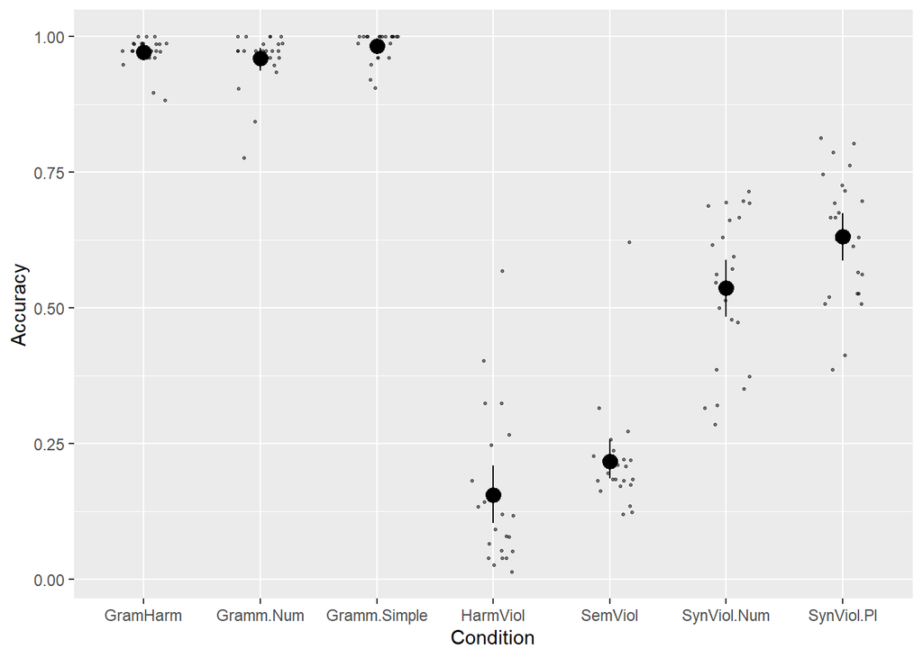

```r
SAVANT_critical %>% group_by(Condition, Item) %>%
  summarise(prop = mean(Accuracy)) %>%
  ggplot(aes(x= Condition , y= prop)) +
  stat_summary(fun.data = mean_cl_boot, size=0.75) +
  geom_jitter(size = 0.5, alpha = 0.5, width = 0.2, height = 0) +
  xlab("Condition") +
  ylab("Accuracy")
```

Accuracy bar plot in 7 conditions

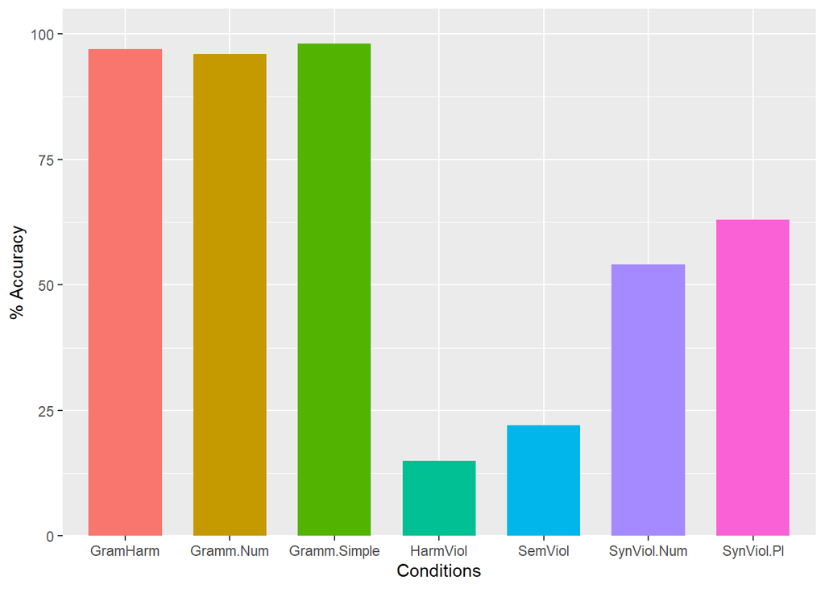

```r
ggplot(Acc_mean,
       aes(x=Condition,y=Mean*100,fill = Condition)) +


  geom_bar(stat = "identity", width = 0.7, position = position_dodge(0.7), show.legend = FALSE  )+
  ylab("% Accuracy") +
  xlab("Conditions") +
  coord_cartesian(ylim = c(0, 100)) +
  scale_y_continuous(expand = expansion(mult = c(0, 0.05)))+
  geom_signif(
    comparisons = "Condition",
    margin_top = 0.12,
    step_increase = 0.09,
    tip_length = 0.05,
    annotation = c("***")
  )
```

#### Generalised Linear Modeling for Accuracy

```r
SAVANT_critical$Condition <- relevel(SAVANT_critical$Condition, ref = "Gramm.Simple")
```

```r
acc.m1 <- glmer (Accuracy ~ Condition + (1  | Participant) + (1  | Trial), data = SAVANT_critical, family = "binomial", control = glmerControl(optimizer = "bobyqa"))
summary(acc.m1)
```

```
## Generalized linear mixed model fit by maximum likelihood (Laplace
##   Approximation) [glmerMod]
##  Family: binomial  ( logit )
## Formula: Accuracy ~ Condition + (1 | Participant) + (1 | Trial)
##    Data: SAVANT_critical
## Control: glmerControl(optimizer = "bobyqa")
##
##      AIC      BIC   logLik deviance df.resid
##   8474.6   8541.7  -4228.3   8456.6    12720
##
## Scaled residuals:
##      Min       1Q   Median       3Q      Max
## -22.9129  -0.3341   0.0907   0.2624  10.5955
##
## Random effects:
##  Groups      Name        Variance Std.Dev.
##  Trial       (Intercept) 0.5876   0.7665
##  Participant (Intercept) 0.9461   0.9727
## Number of obs: 12729, groups:  Trial, 168; Participant, 77
##
## Fixed effects:
##                      Estimate Std. Error z value Pr(>|z|)
## (Intercept)            4.8031     0.2777  17.298   <2e-16 ***
## ConditionGramHarm     -0.5983     0.3310  -1.808   0.0707 .
## ConditionGramm.Num    -0.8693     0.3246  -2.678   0.0074 **
## ConditionHarmViol     -7.0611     0.3139 -22.493   <2e-16 ***
## ConditionSemViol      -6.3801     0.3074 -20.754   <2e-16 ***
## ConditionSynViol.Num  -4.6167     0.3035 -15.209   <2e-16 ***
## ConditionSynViol.Pl   -4.1259     0.3033 -13.604   <2e-16 ***
## ---
## Signif. codes:  0 '***' 0.001 '**' 0.01 '*' 0.05 '.' 0.1 ' ' 1
##
## Correlation of Fixed Effects:
##             (Intr) CndtGH CndG.N CndtHV CndtSV CnSV.N
## CndtnGrmHrm -0.683
## CndtnGrmm.N -0.694  0.578
## CondtnHrmVl -0.757  0.607  0.616
## ConditnSmVl -0.765  0.617  0.627  0.692
## CndtnSynV.N -0.769  0.624  0.634  0.692  0.699
## CndtnSynV.P -0.767  0.625  0.635  0.689  0.697  0.702
```

```r
tab_model(acc.m1)
```

|  | Accuracy |  |  |
| --- | --- | --- | --- |
| Predictors | Odds Ratios | CI | p |
| (Intercept) | 121.89 | 70.73 – 210.04 | **<0.001** |
| Condition [GramHarm] | 0.55 | 0.29 – 1.05 | 0.071 |
| Condition [Gramm.Num] | 0.42 | 0.22 – 0.79 | **0.007** |
| Condition [HarmViol] | 0.00 | 0.00 – 0.00 | **<0.001** |
| Condition [SemViol] | 0.00 | 0.00 – 0.00 | **<0.001** |
| Condition [SynViol.Num] | 0.01 | 0.01 – 0.02 | **<0.001** |
| Condition [SynViol.Pl] | 0.02 | 0.01 – 0.03 | **<0.001** |
| Random Effects |  |  |  |
| σ<sup>2</sup> | 3.29 |  |  |
| τ<sub>00</sub> <sub>Trial</sub> | 0.59 |  |  |
| τ<sub>00</sub> <sub>Participant</sub> | 0.95 |  |  |
| ICC | 0.32 |  |  |
| N <sub>Participant</sub> | 77 |  |  |
| N <sub>Trial</sub> | 168 |  |  |
| Observations | 12729 |  |  |
| Marginal R<sup>2</sup> / Conditional R<sup>2</sup> | 0.599 / 0.726 |  |  |

```r
emmeans(acc.m1, pairwise ~ Condition, adjust = "bonferroni")
```

```
## $emmeans
##  Condition    emmean    SE  df asymp.LCL asymp.UCL
##  Gramm.Simple  4.803 0.278 Inf     4.259     5.347
##  GramHarm      4.205 0.247 Inf     3.720     4.689
##  Gramm.Num     3.934 0.240 Inf     3.464     4.403
##  HarmViol     -2.258 0.209 Inf    -2.668    -1.848
##  SemViol      -1.577 0.202 Inf    -1.974    -1.180
##  SynViol.Num   0.186 0.199 Inf    -0.204     0.577
##  SynViol.Pl    0.677 0.200 Inf     0.286     1.069
##
## Results are given on the logit (not the response) scale.
## Confidence level used: 0.95
##
## $contrasts
##  contrast                   estimate    SE  df z.ratio p.value
##  Gramm.Simple - GramHarm       0.598 0.331 Inf   1.808  1.0000
##  Gramm.Simple - Gramm.Num      0.869 0.325 Inf   2.678  0.1555
##  Gramm.Simple - HarmViol       7.061 0.314 Inf  22.493  <.0001
##  Gramm.Simple - SemViol        6.380 0.307 Inf  20.754  <.0001
##  Gramm.Simple - SynViol.Num    4.617 0.304 Inf  15.209  <.0001
##  Gramm.Simple - SynViol.Pl     4.126 0.303 Inf  13.604  <.0001
##  GramHarm - Gramm.Num          0.271 0.301 Inf   0.899  1.0000
##  GramHarm - HarmViol           6.463 0.286 Inf  22.571  <.0001
##  GramHarm - SemViol            5.782 0.280 Inf  20.642  <.0001
##  GramHarm - SynViol.Num        4.018 0.276 Inf  14.553  <.0001
##  GramHarm - SynViol.Pl         3.528 0.276 Inf  12.785  <.0001
##  Gramm.Num - HarmViol          6.192 0.280 Inf  22.112  <.0001
##  Gramm.Num - SemViol           5.511 0.273 Inf  20.159  <.0001
##  Gramm.Num - SynViol.Num       3.747 0.269 Inf  13.918  <.0001
##  Gramm.Num - SynViol.Pl        3.257 0.269 Inf  12.104  <.0001
##  HarmViol - SemViol           -0.681 0.244 Inf  -2.792  0.1100
##  HarmViol - SynViol.Num       -2.444 0.243 Inf -10.075  <.0001
##  HarmViol - SynViol.Pl        -2.935 0.243 Inf -12.056  <.0001
##  SemViol - SynViol.Num        -1.763 0.237 Inf  -7.445  <.0001
##  SemViol - SynViol.Pl         -2.254 0.238 Inf  -9.488  <.0001
##  SynViol.Num - SynViol.Pl     -0.491 0.234 Inf  -2.095  0.7602
##
## Results are given on the log odds ratio (not the response) scale.
## P value adjustment: bonferroni method for 21 tests
```

Harmony manipulation: Grammatical Harmony vs Harmony Violation

```r
Harmony_Accu <- SAVANT_critical %>% filter(Condition == "GramHarm" | Condition == "HarmViol" )
```

```r
Acc_HarmViol_Model <- glmer (Accuracy ~ Condition + (1  | Participant) + (1  | Trial), data = Harmony_Accu, family = "binomial", control = glmerControl(optimizer = "bobyqa"))
summary(Acc_HarmViol_Model)
```

```
## Generalized linear mixed model fit by maximum likelihood (Laplace
##   Approximation) [glmerMod]
##  Family: binomial  ( logit )
## Formula: Accuracy ~ Condition + (1 | Participant) + (1 | Trial)
##    Data: Harmony_Accu
## Control: glmerControl(optimizer = "bobyqa")
##
##      AIC      BIC   logLik deviance df.resid
##   1856.8   1881.6   -924.4   1848.8     3666
##
## Scaled residuals:
##      Min       1Q   Median       3Q      Max
## -15.4746  -0.2919   0.0955   0.1591   5.8741
##
## Random effects:
##  Groups      Name        Variance Std.Dev.
##  Participant (Intercept) 0.4084   0.6390
##  Trial       (Intercept) 0.8392   0.9161
## Number of obs: 3670, groups:  Participant, 77; Trial, 48
##
## Fixed effects:
##                   Estimate Std. Error z value Pr(>|z|)
## (Intercept)         4.0346     0.2662   15.15   <2e-16 ***
## ConditionHarmViol  -6.1700     0.3381  -18.25   <2e-16 ***
## ---
## Signif. codes:  0 '***' 0.001 '**' 0.01 '*' 0.05 '.' 0.1 ' ' 1
##
## Correlation of Fixed Effects:
##             (Intr)
## CondtnHrmVl -0.758
```

```r
tab_model(Acc_HarmViol_Model)
```

|  | Accuracy |  |  |
| --- | --- | --- | --- |
| Predictors | Odds Ratios | CI | p |
| (Intercept) | 56.52 | 33.54 – 95.24 | **<0.001** |
| Condition [HarmViol] | 0.00 | 0.00 – 0.00 | **<0.001** |
| Random Effects |  |  |  |
| σ<sup>2</sup> | 3.29 |  |  |
| τ<sub>00</sub> <sub>Participant</sub> | 0.41 |  |  |
| τ<sub>00</sub> <sub>Trial</sub> | 0.84 |  |  |
| ICC | 0.27 |  |  |
| N <sub>Participant</sub> | 77 |  |  |
| N <sub>Trial</sub> | 48 |  |  |
| Observations | 3670 |  |  |
| Marginal R<sup>2</sup> / Conditional R<sup>2</sup> | 0.677 / 0.766 |  |  |

```r
emmeans(Acc_HarmViol_Model, pairwise ~ Condition, adjust = "bonferroni")
```

```
## $emmeans
##  Condition emmean    SE  df asymp.LCL asymp.UCL
##  GramHarm    4.03 0.266 Inf      3.51      4.56
##  HarmViol   -2.14 0.221 Inf     -2.57     -1.70
##
## Results are given on the logit (not the response) scale.
## Confidence level used: 0.95
##
## $contrasts
##  contrast            estimate    SE  df z.ratio p.value
##  GramHarm - HarmViol     6.17 0.338 Inf  18.247  <.0001
##
## Results are given on the log odds ratio (not the response) scale.
```

-lar category manipulation (gramsimple vs. synviolpl)

```r
Syn_Pl_Accu <- SAVANT_critical %>% filter(Condition == "SynViol.Pl" | Condition == "Gramm.Simple" )
```

```r
Acc_SynViolPl_Model <- glmer (Accuracy ~ Condition + (1  | Participant) + (1  | Trial), data = Syn_Pl_Accu, family = "binomial", control = glmerControl(optimizer = "bobyqa"))
summary(Acc_SynViolPl_Model)
```

```
## Generalized linear mixed model fit by maximum likelihood (Laplace
##   Approximation) [glmerMod]
##  Family: binomial  ( logit )
## Formula: Accuracy ~ Condition + (1 | Participant) + (1 | Trial)
##    Data: Syn_Pl_Accu
## Control: glmerControl(optimizer = "bobyqa")
##
##      AIC      BIC   logLik deviance df.resid
##   2272.9   2297.6  -1132.4   2264.9     3616
##
## Scaled residuals:
##      Min       1Q   Median       3Q      Max
## -26.4134   0.0349   0.0988   0.3286   2.9150
##
## Random effects:
##  Groups      Name        Variance Std.Dev.
##  Participant (Intercept) 1.889    1.3744
##  Trial       (Intercept) 0.603    0.7765
## Number of obs: 3620, groups:  Participant, 77; Trial, 48
##
## Fixed effects:
##                     Estimate Std. Error z value Pr(>|z|)
## (Intercept)           5.1775     0.3328   15.56   <2e-16 ***
## ConditionSynViol.Pl  -4.4036     0.3338  -13.19   <2e-16 ***
## ---
## Signif. codes:  0 '***' 0.001 '**' 0.01 '*' 0.05 '.' 0.1 ' ' 1
##
## Correlation of Fixed Effects:
##             (Intr)
## CndtnSynV.P -0.757
```

```r
emmeans(Acc_SynViolPl_Model, pairwise ~ Condition, adjust = "bonferroni")
```

```
## $emmeans
##  Condition    emmean    SE  df asymp.LCL asymp.UCL
##  Gramm.Simple  5.177 0.333 Inf     4.525      5.83
##  SynViol.Pl    0.774 0.233 Inf     0.318      1.23
##
## Results are given on the logit (not the response) scale.
## Confidence level used: 0.95
##
## $contrasts
##  contrast                  estimate    SE  df z.ratio p.value
##  Gramm.Simple - SynViol.Pl      4.4 0.334 Inf  13.191  <.0001
##
## Results are given on the log odds ratio (not the response) scale.
```

Num -lar manipulation (GramNum, SynViolNum, SemViol)

```r
NumViol_Accu <- SAVANT_critical %>% filter(Condition == "Gramm.Num" | Condition == "SynViol.Num" | Condition == "SemViol" )
```

```r
Acc_SynViolNum_Model <- glmer (Accuracy ~ Condition + (1  | Participant) + (1  | Trial), data = NumViol_Accu, family = "binomial", control = glmerControl(optimizer = "bobyqa"))
summary(Acc_SynViolNum_Model)
```

```
## Generalized linear mixed model fit by maximum likelihood (Laplace
##   Approximation) [glmerMod]
##  Family: binomial  ( logit )
## Formula: Accuracy ~ Condition + (1 | Participant) + (1 | Trial)
##    Data: NumViol_Accu
## Control: glmerControl(optimizer = "bobyqa")
##
##      AIC      BIC   logLik deviance df.resid
##   4134.6   4167.6  -2062.3   4124.6     5434
##
## Scaled residuals:
##      Min       1Q   Median       3Q      Max
## -30.6625  -0.4103   0.0847   0.3174   6.5405
##
## Random effects:
##  Groups      Name        Variance Std.Dev.
##  Participant (Intercept) 1.7264   1.3139
##  Trial       (Intercept) 0.5146   0.7174
## Number of obs: 5439, groups:  Participant, 77; Trial, 72
##
## Fixed effects:
##                      Estimate Std. Error z value Pr(>|z|)
## (Intercept)            4.1177     0.2582   15.95   <2e-16 ***
## ConditionSemViol      -5.8321     0.2711  -21.51   <2e-16 ***
## ConditionSynViol.Num  -3.8635     0.2620  -14.75   <2e-16 ***
## ---
## Signif. codes:  0 '***' 0.001 '**' 0.01 '*' 0.05 '.' 0.1 ' ' 1
##
## Correlation of Fixed Effects:
##             (Intr) CndtSV
## ConditnSmVl -0.651
## CndtnSynV.N -0.652  0.638
```

```r
emmeans(Acc_SynViolNum_Model, pairwise ~ Condition, adjust = "bonferroni")
```

```
## $emmeans
##  Condition   emmean    SE  df asymp.LCL asymp.UCL
##  Gramm.Num    4.118 0.258 Inf     3.612      4.62
##  SemViol     -1.714 0.221 Inf    -2.148     -1.28
##  SynViol.Num  0.254 0.217 Inf    -0.171      0.68
##
## Results are given on the logit (not the response) scale.
## Confidence level used: 0.95
##
## $contrasts
##  contrast                estimate    SE  df z.ratio p.value
##  Gramm.Num - SemViol         5.83 0.271 Inf  21.511  <.0001
##  Gramm.Num - SynViol.Num     3.86 0.262 Inf  14.746  <.0001
##  SemViol - SynViol.Num      -1.97 0.227 Inf  -8.671  <.0001
##
## Results are given on the log odds ratio (not the response) scale.
## P value adjustment: bonferroni method for 3 tests
```

```r
Sem_Syn_Pl_Viol_Accu <- SAVANT_critical %>% filter(Condition == "Gramm.Num" | Condition == "SynViol.Pl" | Condition == "SemViol" )
```

```r
Acc_Sem_Syn_Pl_Viol_Model <- glmer (Accuracy ~ Condition + (1  | Participant) + (1  | Trial), data = NumViol_Accu, family = "binomial", control = glmerControl(optimizer = "bobyqa"))
summary(Acc_Sem_Syn_Pl_Viol_Model)
```

```
## Generalized linear mixed model fit by maximum likelihood (Laplace
##   Approximation) [glmerMod]
##  Family: binomial  ( logit )
## Formula: Accuracy ~ Condition + (1 | Participant) + (1 | Trial)
##    Data: NumViol_Accu
## Control: glmerControl(optimizer = "bobyqa")
##
##      AIC      BIC   logLik deviance df.resid
##   4134.6   4167.6  -2062.3   4124.6     5434
##
## Scaled residuals:
##      Min       1Q   Median       3Q      Max
## -30.6625  -0.4103   0.0847   0.3174   6.5405
##
## Random effects:
##  Groups      Name        Variance Std.Dev.
##  Participant (Intercept) 1.7264   1.3139
##  Trial       (Intercept) 0.5146   0.7174
## Number of obs: 5439, groups:  Participant, 77; Trial, 72
##
## Fixed effects:
##                      Estimate Std. Error z value Pr(>|z|)
## (Intercept)            4.1177     0.2582   15.95   <2e-16 ***
## ConditionSemViol      -5.8321     0.2711  -21.51   <2e-16 ***
## ConditionSynViol.Num  -3.8635     0.2620  -14.75   <2e-16 ***
## ---
## Signif. codes:  0 '***' 0.001 '**' 0.01 '*' 0.05 '.' 0.1 ' ' 1
##
## Correlation of Fixed Effects:
##             (Intr) CndtSV
## ConditnSmVl -0.651
## CndtnSynV.N -0.652  0.638
```

```r
emmeans(Acc_Sem_Syn_Pl_Viol_Model, pairwise ~ Condition, adjust = "bonferroni")
```

```
## $emmeans
##  Condition   emmean    SE  df asymp.LCL asymp.UCL
##  Gramm.Num    4.118 0.258 Inf     3.612      4.62
##  SemViol     -1.714 0.221 Inf    -2.148     -1.28
##  SynViol.Num  0.254 0.217 Inf    -0.171      0.68
##
## Results are given on the logit (not the response) scale.
## Confidence level used: 0.95
##
## $contrasts
##  contrast                estimate    SE  df z.ratio p.value
##  Gramm.Num - SemViol         5.83 0.271 Inf  21.511  <.0001
##  Gramm.Num - SynViol.Num     3.86 0.262 Inf  14.746  <.0001
##  SemViol - SynViol.Num      -1.97 0.227 Inf  -8.671  <.0001
##
## Results are given on the log odds ratio (not the response) scale.
## P value adjustment: bonferroni method for 3 tests
```

## Reaction Time

```r
SAVANT_Task$TrialUniqueID <- paste(SAVANT_Task$Participant," / ", SAVANT_Task$Trial.Number)
```

If participants have responded in 2 objects, I will take into account the first object.

```r
TrialWithBoth = SAVANT_Task$TrialUniqueID[SAVANT_Task$Object == "object-121" & SAVANT_Task$TrialUniqueID %in%
SAVANT_Task$TrialUniqueID[SAVANT_Task$Object == "object-124"]]

SAVANT_Task = SAVANT_Task[!(SAVANT_Task$TrialUniqueID %in% TrialWithBoth & SAVANT_Task$Object == "object-121"),]
```

In the data, there are ‘Response Type’, ‘Response’, and ‘Reaction Time’ columns. The value in the ‘Reaction Time’ column where the Response Type is ‘response’ and the Response is ‘yes’ or ‘no’ will give the time since screen start at which the participant pressed the response key.

The values in the Reaction Time column are counted from the start of the screen. If the participant responded in object-124 with the audio clip, then this value minus the value in the ‘audio start’ row will correspond to the participant’s reaction time since audio onset. If the participant instead responded on object-121 with only the response button, then I will need to add together the Reaction Time value in the row with the response type ‘continue’ from object-44 (this gives the duration of the audio screen) to the Reaction Time value in the row with the response type ‘response’ from object-121 (this gives the time after the start of the third screen at which the participant pressed the response key). I will then subtract the value in the ‘audio start’ row to calculate the participant’s reaction time since audio onset.

```r
Data_121 <- SAVANT_Task %>% filter(Object == "object-121")
Data_44_continue <- SAVANT_Task %>% filter(Object == "object-44" & Response.Type == "continue")
Data_121_44 <- rbind(Data_121, Data_44_continue)
```

```r
RT_121 <- Data_121_44 %>% group_by(TrialUniqueID) %>%
  summarise(Total_RT = sum(RT))
```

```r
Data_121_final <- merge(RT_121, Data_121, by = c("TrialUniqueID"))
```

```r
Data_124 <- SAVANT_Task %>% filter(Object == "object-124")
Data_44_audio_started <- SAVANT_Task %>% filter(Object == "object-44" & Response == "audio started")
Data_124_44 <- rbind(Data_124, Data_44_audio_started)
```

```r
RT_124 <- Data_124_44 %>% group_by(TrialUniqueID) %>%
  arrange(TrialUniqueID, Object) %>%
  mutate(Total_RT = lag(RT) - RT) %>%
  filter(!is.na(Total_RT)) %>%
  select(Total_RT, TrialUniqueID)
```

```r
Data_124_final <- merge(Data_124, RT_124, by = c("TrialUniqueID"))
```

Combining both 121 and 124

```r
Data_121_124 <- rbind(Data_124_final, Data_121_final)
```

Filtering for correct answers in order to generate means for reaction time

```r
SAVANT_RT <- Data_121_124 %>% filter(Accuracy == 1, Set == "critical")

view(SAVANT_RT)
```

```r
str(SAVANT_RT)
```

```
## 'data.frame':    8113 obs. of  23 variables:
##  $ TrialUniqueID      : chr  "9216758  /  12" "9216758  /  137" "9216758  /  5" "9216758  /  62" ...
##  $ Participant        : int  9216758 9216758 9216758 9216758 9216758 9217237 9217237 9217237 9217237 9217237 ...
##  $ Mean_LanUse_Persian: num  67.5 67.5 67.5 67.5 67.5 72.5 72.5 72.5 72.5 72.5 ...
##  $ Mean_LanUse        : num  30 30 30 30 30 27.5 27.5 27.5 27.5 27.5 ...
##  $ Mean_Proficiency   : num  57.1 57.1 57.1 57.1 57.1 ...
##  $ RT                 : num  966 1070 674 819 888 ...
##  $ Participant.Status : chr  "complete" "complete" "complete" "complete" ...
##  $ Completion.Code    : chr  "ovydht" "ovydht" "ovydht" "ovydht" ...
##  $ Device.Type        : chr  "computer" "computer" "computer" "computer" ...
##  $ Trial.Number       : int  12 137 5 62 93 173 181 182 23 28 ...
##  $ Response.Type      : chr  "response" "response" "response" "response" ...
##  $ Response           : chr  "acceptable" "acceptable" "acceptable" "acceptable" ...
##  $ Accuracy           : num  1 1 1 1 1 1 1 1 1 1 ...
##  $ Display            : chr  "trial" "trial" "trial" "trial" ...
##  $ Component.Name     : chr  "Keyboard Response" "Keyboard Response" "Keyboard Response" "Keyboard Response" ...
##  $ Condition          : chr  "Gramm.Num" "Gramm.Num" "GramHarm" "Gramm.Simple" ...
##  $ Answer             : chr  "acceptable" "acceptable" "unacceptable" "acceptable" ...
##  $ Item               : chr  "üç ulduz" "dörd yumurta" "öldy" "inəklər" ...
##  $ Trial              : int  40 41 124 12 7 5 133 19 10 21 ...
##  $ Freq               : chr  "3791" "2,137" "1,145" "99" ...
##  $ Set                : chr  "critical" "critical" "critical" "critical" ...
##  $ Object             : chr  "object-124" "object-124" "object-124" "object-124" ...
##  $ Total_RT           : num  961 1064 668 813 881 ...
```

```r
summary(SAVANT_RT$Total_RT)
```

```
##    Min. 1st Qu.  Median    Mean 3rd Qu.    Max.
##       6    1027    1224    1274    1464    2719
```

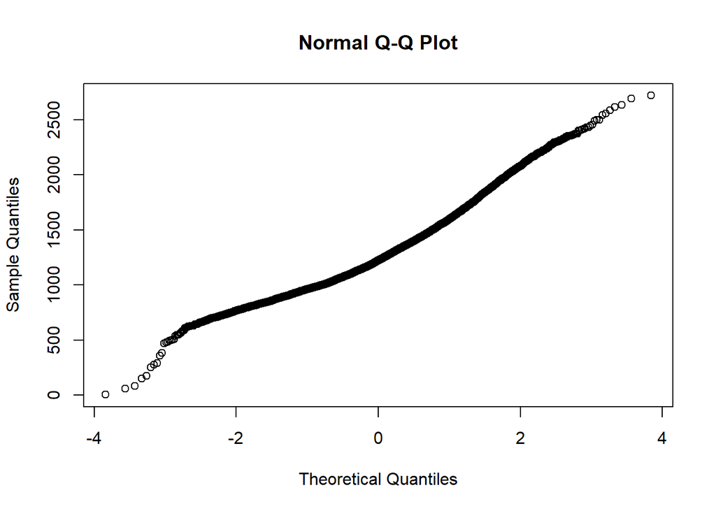

```r
qqnorm(SAVANT_RT$Total_RT)
```

```r
SAVANT_RT2 <- SAVANT_RT %>% filter(Total_RT > 200)
(nrow(SAVANT_RT) - nrow(SAVANT_RT2)) / nrow(SAVANT_RT)*100
```

```
## [1] 0.06162948
```

Checking whether data is normaly distributed

```r
SAVANT_RT2$Log_RT <- log(SAVANT_RT2$Total_RT)
```

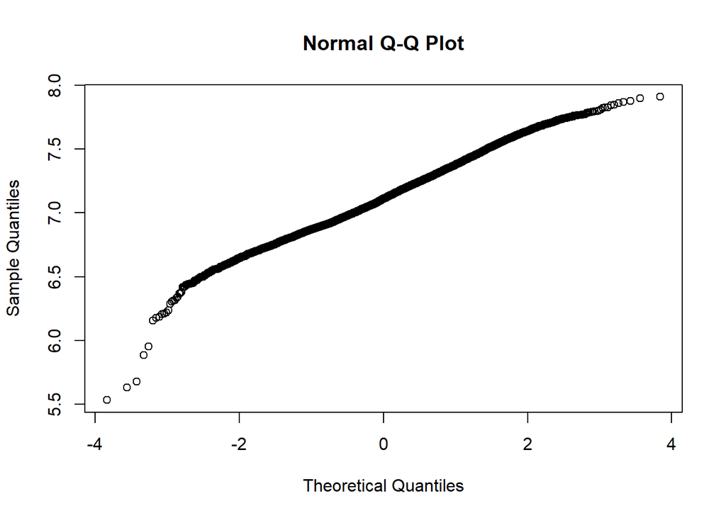

```r
qqnorm(SAVANT_RT2$Log_RT)
```

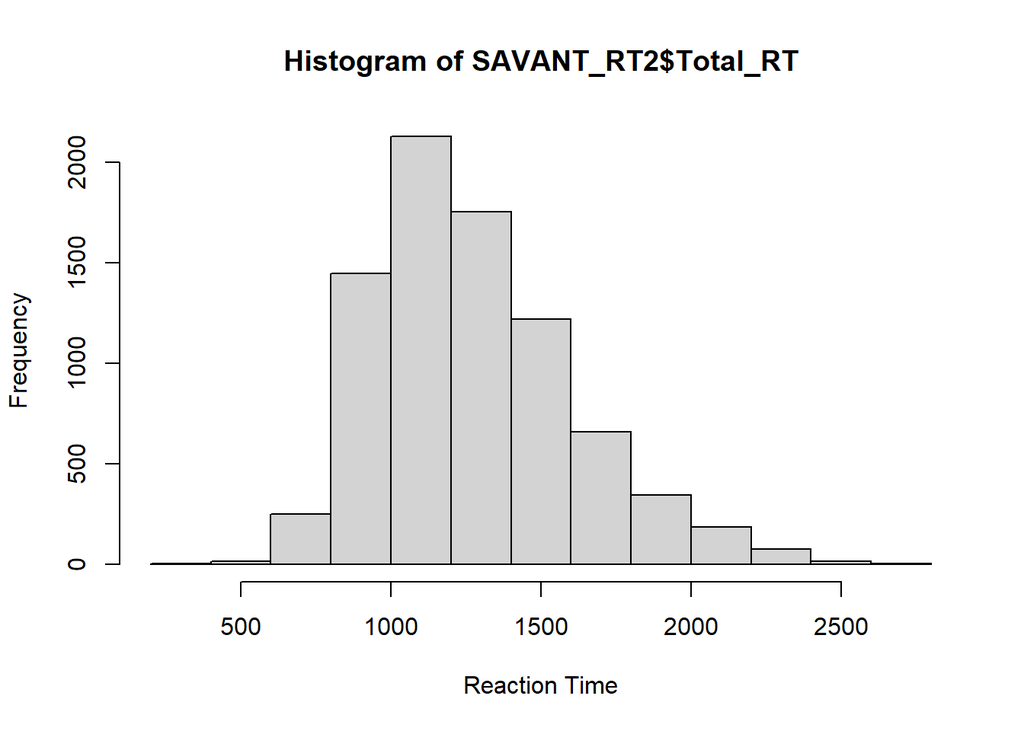

```r
hist(SAVANT_RT2$Total_RT, xlab = "Reaction Time")
```

Checking how the distribution looks like for the random factor of participant

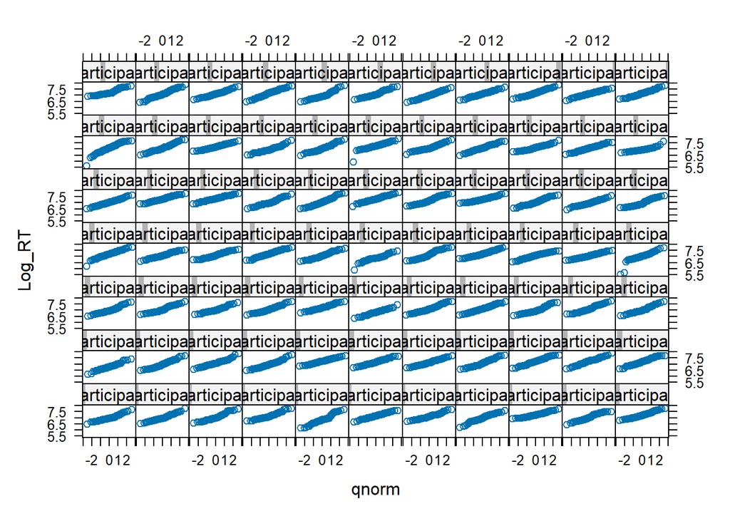

```r
qqmath(~Log_RT|Participant, data = SAVANT_RT2)
```

```r
table(SAVANT_RT2$Participant)
```

```
##
## 9216758 9217237 9217683 9217896 9217946 9217967 9221421 9221735 9224874 9232862
##      95      96      92      95      83      93      96     104     132      94
## 9233109 9233675 9233740 9234466 9234672 9237613 9239266 9239415 9240504 9241138
##     118      79     106     109     113     123     112     117      99     134
## 9243037 9255695 9263836 9265938 9266541 9266761 9267518 9267703 9282211 9283613
##     110     123      85     100      76     103      85      75     120     134
## 9284773 9295713 9296372 9301932 9302145 9308196 9309253 9340554 9340556 9340633
##      87     101      87     112     101     115     121     108      74     109
## 9341704 9341830 9341945 9342048 9343579 9344867 9345197 9347028 9353510 9376385
##     142     142     138      79     111     108     123      91     111     118
## 9377034 9391632 9391791 9393177 9393357 9393588 9393806 9394993 9395012 9395027
##     119     115     102     102      97     106     101     110      93      94
## 9396974 9397582 9399009 9404969 9405075 9405294 9406319 9410457 9410461 9431250
##     110     111     108     110     134      72      84     122     108     122
## 9481489 9505769 9506472 9508509 9677314 9709165 9710186
##      86      80      92     104     112     120     115
```

box whisker plots per condition

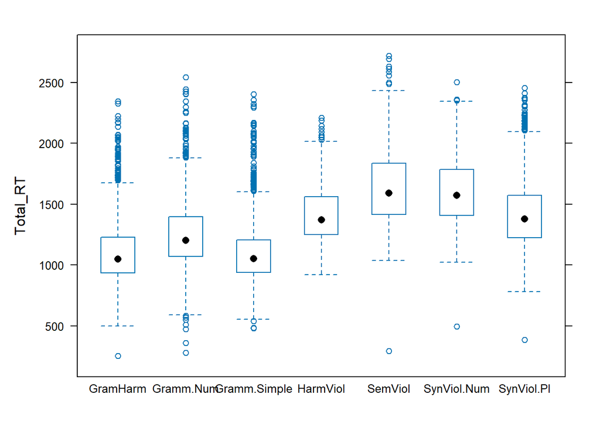

```r
bwplot(Total_RT ~ Condition, data = SAVANT_RT2 )
```

The reason that syntactic plural violation items have been responded to faster compared with syntactic numeral violatiuon is probably because SynViol.Num items are longer in syllable.

Reaction Time means per condition and standard error and standard deviation

```r
SAVANT_RT_means <- SAVANT_RT2 %>% group_by(Condition) %>% summarise(Mean = round(mean(Total_RT),2), Standard_Deviation = round(sd(Total_RT),2), Standard_Error = round(std.error(Total_RT),3)
)

view(SAVANT_RT_means)
SAVANT_RT_means
```

```
## # A tibble: 7 × 4
##   Condition     Mean Standard_Deviation Standard_Error
##   <chr>        <dbl>              <dbl>          <dbl>
## 1 GramHarm     1101.               255.           6.05
## 2 Gramm.Num    1247.               269            6.41
## 3 Gramm.Simple 1097.               251.           5.90
## 4 HarmViol     1425.               258.          15.4
## 5 SemViol      1647.               324.          16.4
## 6 SynViol.Num  1608.               270.           8.69
## 7 SynViol.Pl   1428.               293.           8.72
```

Let’s look at the effect of fatigue

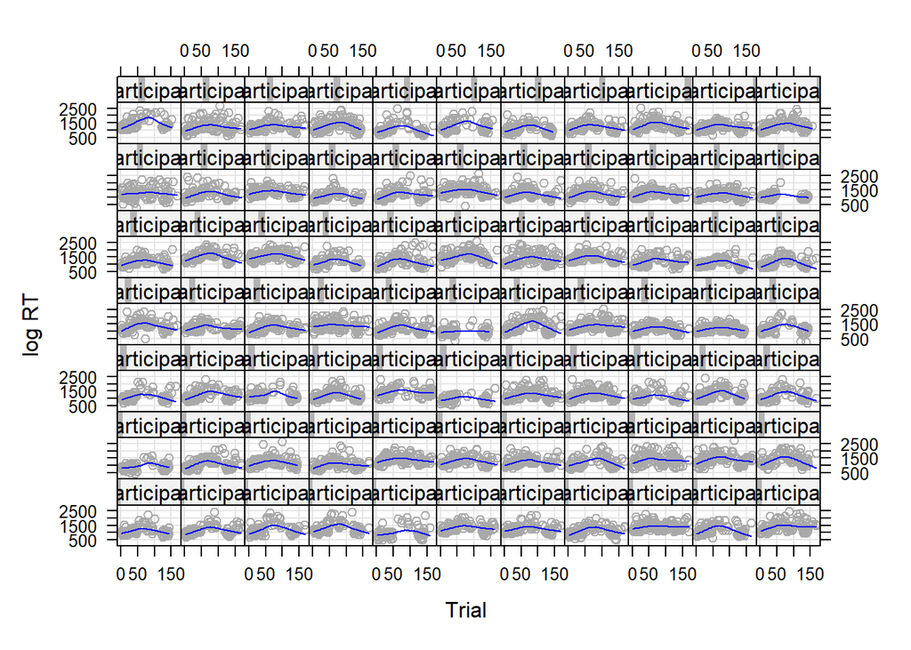

```r
xylowess.fnc(Total_RT ~ Trial | Participant, data = SAVANT_RT2, ylab = "log RT")
```

```r
str(SAVANT_RT2)
```

```
## 'data.frame':    8108 obs. of  24 variables:
##  $ TrialUniqueID      : chr  "9216758  /  12" "9216758  /  137" "9216758  /  5" "9216758  /  62" ...
##  $ Participant        : int  9216758 9216758 9216758 9216758 9216758 9217237 9217237 9217237 9217237 9217237 ...
##  $ Mean_LanUse_Persian: num  67.5 67.5 67.5 67.5 67.5 72.5 72.5 72.5 72.5 72.5 ...
##  $ Mean_LanUse        : num  30 30 30 30 30 27.5 27.5 27.5 27.5 27.5 ...
##  $ Mean_Proficiency   : num  57.1 57.1 57.1 57.1 57.1 ...
##  $ RT                 : num  966 1070 674 819 888 ...
##  $ Participant.Status : chr  "complete" "complete" "complete" "complete" ...
##  $ Completion.Code    : chr  "ovydht" "ovydht" "ovydht" "ovydht" ...
##  $ Device.Type        : chr  "computer" "computer" "computer" "computer" ...
##  $ Trial.Number       : int  12 137 5 62 93 173 181 182 23 28 ...
##  $ Response.Type      : chr  "response" "response" "response" "response" ...
##  $ Response           : chr  "acceptable" "acceptable" "acceptable" "acceptable" ...
##  $ Accuracy           : num  1 1 1 1 1 1 1 1 1 1 ...
##  $ Display            : chr  "trial" "trial" "trial" "trial" ...
##  $ Component.Name     : chr  "Keyboard Response" "Keyboard Response" "Keyboard Response" "Keyboard Response" ...
##  $ Condition          : chr  "Gramm.Num" "Gramm.Num" "GramHarm" "Gramm.Simple" ...
##  $ Answer             : chr  "acceptable" "acceptable" "unacceptable" "acceptable" ...
##  $ Item               : chr  "üç ulduz" "dörd yumurta" "öldy" "inəklər" ...
##  $ Trial              : int  40 41 124 12 7 5 133 19 10 21 ...
##  $ Freq               : chr  "3791" "2,137" "1,145" "99" ...
##  $ Set                : chr  "critical" "critical" "critical" "critical" ...
##  $ Object             : chr  "object-124" "object-124" "object-124" "object-124" ...
##  $ Total_RT           : num  961 1064 668 813 881 ...
##  $ Log_RT             : num  6.87 6.97 6.5 6.7 6.78 ...
```

```r
SAVANT_RT2 <- SAVANT_RT2 %>% mutate (Participant = as.factor(Participant),
          Trial.Number = as.factor(Trial.Number),
          Condition = as.factor(Condition),
          Item = as.factor(Item),
          Trial = as.factor(Trial),
          Freq = as.factor(Freq)
    )
```

```r
SAVANT_RT2$Condition <- relevel(SAVANT_RT2$Condition, ref = "Gramm.Simple")
```

#### Linear mixed modelling for reaction time

```r
RT_M1 <- lmer(Total_RT ~ Condition + (1  | Participant) + (1  | Trial), data=SAVANT_RT2)
tab_model(RT_M1)
```

|  | Total_RT |  |  |
| --- | --- | --- | --- |
| Predictors | Estimates | CI | p |
| (Intercept) | 1098.99 | 1059.61 – 1138.36 | **<0.001** |
| Condition [GramHarm] | 4.12 | -39.70 – 47.94 | 0.854 |
| Condition [Gramm.Num] | 152.08 | 108.24 – 195.92 | **<0.001** |
| Condition [HarmViol] | 299.67 | 245.81 – 353.54 | **<0.001** |
| Condition [SemViol] | 517.89 | 468.54 – 567.24 | **<0.001** |
| Condition [SynViol.Num] | 500.05 | 454.85 – 545.25 | **<0.001** |
| Condition [SynViol.Pl] | 325.57 | 280.83 – 370.30 | **<0.001** |
| Random Effects |  |  |  |
| σ<sup>2</sup> | 55368.86 |  |  |
| τ<sub>00</sub> <sub>Trial</sub> | 5254.04 |  |  |
| τ<sub>00</sub> <sub>Participant</sub> | 11845.78 |  |  |
| ICC | 0.24 |  |  |
| N <sub>Participant</sub> | 77 |  |  |
| N <sub>Trial</sub> | 168 |  |  |
| Observations | 8108 |  |  |
| Marginal R<sup>2</sup> / Conditional R<sup>2</sup> | 0.327 / 0.486 |  |  |

```r
summary(RT_M1)
```

```
## Linear mixed model fit by REML. t-tests use Satterthwaite's method [
## lmerModLmerTest]
## Formula: Total_RT ~ Condition + (1 | Participant) + (1 | Trial)
##    Data: SAVANT_RT2
##
## REML criterion at convergence: 112007.5
##
## Scaled residuals:
##     Min      1Q  Median      3Q     Max
## -5.3586 -0.6288 -0.1603  0.4177  5.6827
##
## Random effects:
##  Groups      Name        Variance Std.Dev.
##  Trial       (Intercept)  5254     72.48
##  Participant (Intercept) 11846    108.84
##  Residual                55369    235.31
## Number of obs: 8108, groups:  Trial, 168; Participant, 77
##
## Fixed effects:
##                      Estimate Std. Error      df t value Pr(>|t|)
## (Intercept)           1098.99      20.09  192.74  54.710  < 2e-16 ***
## ConditionGramHarm        4.12      22.35  123.79   0.184    0.854
## ConditionGramm.Num     152.08      22.36  124.03   6.800 3.93e-10 ***
## ConditionHarmViol      299.68      27.48  230.79  10.905  < 2e-16 ***
## ConditionSemViol       517.89      25.17  195.69  20.572  < 2e-16 ***
## ConditionSynViol.Num   500.05      23.06  139.64  21.685  < 2e-16 ***
## ConditionSynViol.Pl    325.57      22.82  134.30  14.266  < 2e-16 ***
## ---
## Signif. codes:  0 '***' 0.001 '**' 0.01 '*' 0.05 '.' 0.1 ' ' 1
##
## Correlation of Fixed Effects:
##             (Intr) CndtGH CndG.N CndtHV CndtSV CnSV.N
## CndtnGrmHrm -0.556
## CndtnGrmm.N -0.556  0.499
## CondtnHrmVl -0.453  0.406  0.406
## ConditnSmVl -0.494  0.444  0.443  0.361
## CndtnSynV.N -0.539  0.484  0.484  0.395  0.434
## CndtnSynV.P -0.545  0.489  0.489  0.398  0.438  0.477
```

Let’s extract fitted values and compare these with the actual values

```r
fitted(RT_M1)[1:4]
```

```
##         1         2         3         4
## 1134.8341 1098.4947  935.9675  972.0002
```

```r
SAVANT_RT2$Total_RT[1:4]
```

```
## [1]  960.802 1063.700  667.600  813.000
```

Harmony manipulation (gramharm vs. harmviol)

```r
RT_Harmony <- SAVANT_RT2 %>%
  filter(Condition == "HarmViol" | Condition == "GramHarm")
```

```r
RT_Harmony_Model <- lmer(Total_RT ~ Condition + (1  | Participant) + (1  | Trial), data = RT_Harmony)
tab_model(RT_Harmony_Model)
```

|  | Total_RT |  |  |
| --- | --- | --- | --- |
| Predictors | Estimates | CI | p |
| (Intercept) | 1102.89 | 1065.60 – 1140.17 | **<0.001** |
| Condition [HarmViol] | 305.69 | 254.93 – 356.45 | **<0.001** |
| Random Effects |  |  |  |
| σ<sup>2</sup> | 50052.51 |  |  |
| τ<sub>00</sub> <sub>Participant</sub> | 11614.86 |  |  |
| τ<sub>00</sub> <sub>Trial</sub> | 4380.16 |  |  |
| ICC | 0.24 |  |  |
| N <sub>Participant</sub> | 77 |  |  |
| N <sub>Trial</sub> | 48 |  |  |
| Observations | 2066 |  |  |
| Marginal R<sup>2</sup> / Conditional R<sup>2</sup> | 0.143 / 0.350 |  |  |

```r
summary(RT_Harmony_Model)
```

```
## Linear mixed model fit by REML. t-tests use Satterthwaite's method [
## lmerModLmerTest]
## Formula: Total_RT ~ Condition + (1 | Participant) + (1 | Trial)
##    Data: RT_Harmony
##
## REML criterion at convergence: 28414.8
##
## Scaled residuals:
##     Min      1Q  Median      3Q     Max
## -3.5006 -0.5996 -0.1706  0.3872  5.4092
##
## Random effects:
##  Groups      Name        Variance Std.Dev.
##  Participant (Intercept) 11615    107.77
##  Trial       (Intercept)  4380     66.18
##  Residual                50053    223.72
## Number of obs: 2066, groups:  Participant, 77; Trial, 48
##
## Fixed effects:
##                   Estimate Std. Error      df t value Pr(>|t|)
## (Intercept)        1102.89      19.01   65.66   58.01   <2e-16 ***
## ConditionHarmViol   305.69      25.88   56.44   11.81   <2e-16 ***
## ---
## Signif. codes:  0 '***' 0.001 '**' 0.01 '*' 0.05 '.' 0.1 ' ' 1
##
## Correlation of Fixed Effects:
##             (Intr)
## CondtnHrmVl -0.430
```

```r
emmeans(RT_Harmony_Model, pairwise ~ Condition, adjust = "bonferroni")
```

```
## $emmeans
##  Condition emmean   SE    df lower.CL upper.CL
##  GramHarm    1103 19.0  68.4     1065     1141
##  HarmViol    1409 24.7 133.7     1360     1457
##
## Degrees-of-freedom method: kenward-roger
## Confidence level used: 0.95
##
## $contrasts
##  contrast            estimate   SE df t.ratio p.value
##  GramHarm - HarmViol     -306 25.9 59 -11.783  <.0001
##
## Degrees-of-freedom method: kenward-roger
```

-lar category manipulation (gramsimple vs. synviolpl)

```r
RT_SynViolPl <- SAVANT_RT2 %>%
  filter(Condition == "Gramm.Simple" | Condition == "SynViol.Pl")
```

```r
RT_SynViolPl_Model <- lmer(Total_RT ~ Condition + (1  | Participant) + (1  | Trial), data = RT_SynViolPl)
tab_model(RT_SynViolPl_Model)
```

|  | Total_RT |  |  |
| --- | --- | --- | --- |
| Predictors | Estimates | CI | p |
| (Intercept) | 1098.80 | 1061.36 – 1136.24 | **<0.001** |
| Condition [SynViol.Pl] | 332.51 | 290.59 – 374.43 | **<0.001** |
| Random Effects |  |  |  |
| σ<sup>2</sup> | 56077.63 |  |  |
| τ<sub>00</sub> <sub>Participant</sub> | 11404.83 |  |  |
| τ<sub>00</sub> <sub>Trial</sub> | 4448.28 |  |  |
| ICC | 0.22 |  |  |
| N <sub>Participant</sub> | 77 |  |  |
| N <sub>Trial</sub> | 48 |  |  |
| Observations | 2929 |  |  |
| Marginal R<sup>2</sup> / Conditional R<sup>2</sup> | 0.267 / 0.428 |  |  |

```r
summary(RT_SynViolPl_Model)
```

```
## Linear mixed model fit by REML. t-tests use Satterthwaite's method [
## lmerModLmerTest]
## Formula: Total_RT ~ Condition + (1 | Participant) + (1 | Trial)
##    Data: RT_SynViolPl
##
## REML criterion at convergence: 40569.9
##
## Scaled residuals:
##     Min      1Q  Median      3Q     Max
## -4.8867 -0.6143 -0.1588  0.3693  5.4246
##
## Random effects:
##  Groups      Name        Variance Std.Dev.
##  Participant (Intercept) 11405    106.8
##  Trial       (Intercept)  4448     66.7
##  Residual                56078    236.8
## Number of obs: 2929, groups:  Participant, 77; Trial, 48
##
## Fixed effects:
##                     Estimate Std. Error      df t value Pr(>|t|)
## (Intercept)          1098.80      19.10   88.94   57.54   <2e-16 ***
## ConditionSynViol.Pl   332.51      21.38   46.27   15.55   <2e-16 ***
## ---
## Signif. codes:  0 '***' 0.001 '**' 0.01 '*' 0.05 '.' 0.1 ' ' 1
##
## Correlation of Fixed Effects:
##             (Intr)
## CndtnSynV.P -0.530
```

```r
emmeans(RT_SynViolPl_Model, pairwise ~ Condition, adjust = "bonferroni")
```

```
## $emmeans
##  Condition    emmean   SE    df lower.CL upper.CL
##  Gramm.Simple   1099 19.1  89.8     1061     1137
##  SynViol.Pl     1431 19.7 101.5     1392     1470
##
## Degrees-of-freedom method: kenward-roger
## Confidence level used: 0.95
##
## $contrasts
##  contrast                  estimate   SE   df t.ratio p.value
##  Gramm.Simple - SynViol.Pl     -333 21.4 46.9 -15.551  <.0001
##
## Degrees-of-freedom method: kenward-roger
```

Num -lar manipulation (GramNum, SynViolNum, SemViol)

```r
RT_SynViolNum <- SAVANT_RT2 %>%
  filter(Condition == "Gramm.Num" | Condition == "SynViol.Num" | Condition == "SemViol" )
```

```r
RT_SynViolNum_Model <- lmer(Total_RT ~ Condition + (1  | Participant) + (1  | Trial), data = RT_SynViolNum)
tab_model(RT_SynViolNum_Model)
```

|  | Total_RT |  |  |
| --- | --- | --- | --- |
| Predictors | Estimates | CI | p |
| (Intercept) | 1251.45 | 1207.84 – 1295.06 | **<0.001** |
| Condition [SemViol] | 371.47 | 317.21 – 425.73 | **<0.001** |
| Condition [SynViol.Num] | 346.02 | 296.23 – 395.82 | **<0.001** |
| Random Effects |  |  |  |
| σ<sup>2</sup> | 56530.54 |  |  |
| τ<sub>00</sub> <sub>Participant</sub> | 14654.90 |  |  |
| τ<sub>00</sub> <sub>Trial</sub> | 6527.49 |  |  |
| ICC | 0.27 |  |  |
| N <sub>Participant</sub> | 77 |  |  |
| N <sub>Trial</sub> | 72 |  |  |
| Observations | 3113 |  |  |
| Marginal R<sup>2</sup> / Conditional R<sup>2</sup> | 0.283 / 0.479 |  |  |

```r
summary(RT_SynViolNum_Model)
```

```
## Linear mixed model fit by REML. t-tests use Satterthwaite's method [
## lmerModLmerTest]
## Formula: Total_RT ~ Condition + (1 | Participant) + (1 | Trial)
##    Data: RT_SynViolNum
##
## REML criterion at convergence: 43174.6
##
## Scaled residuals:
##     Min      1Q  Median      3Q     Max
## -5.3296 -0.6466 -0.1388  0.4666  4.6502
##
## Random effects:
##  Groups      Name        Variance Std.Dev.
##  Participant (Intercept) 14655    121.06
##  Trial       (Intercept)  6527     80.79
##  Residual                56531    237.76
## Number of obs: 3113, groups:  Participant, 77; Trial, 72
##
## Fixed effects:
##                      Estimate Std. Error      df t value Pr(>|t|)
## (Intercept)           1251.45      22.24  108.04   56.27   <2e-16 ***
## ConditionSemViol       371.47      27.67   86.01   13.42   <2e-16 ***
## ConditionSynViol.Num   346.02      25.40   61.83   13.62   <2e-16 ***
## ---
## Signif. codes:  0 '***' 0.001 '**' 0.01 '*' 0.05 '.' 0.1 ' ' 1
##
## Correlation of Fixed Effects:
##             (Intr) CndtSV
## ConditnSmVl -0.495
## CndtnSynV.N -0.539  0.442
```

```r
emmeans(RT_SynViolNum_Model, pairwise ~ Condition, adjust = "bonferroni", pbkrtest.limit = 3113)
```

```
## $emmeans
##  Condition   emmean   SE  df lower.CL upper.CL
##  Gramm.Num     1251 22.2 106     1207     1296
##  SemViol       1623 25.5 178     1573     1673
##  SynViol.Num   1597 23.0 121     1552     1643
##
## Degrees-of-freedom method: kenward-roger
## Confidence level used: 0.95
##
## $contrasts
##  contrast                estimate   SE   df t.ratio p.value
##  Gramm.Num - SemViol       -371.5 27.7 83.6 -13.420  <.0001
##  Gramm.Num - SynViol.Num   -346.0 25.4 60.1 -13.624  <.0001
##  SemViol - SynViol.Num       25.4 28.1 88.6   0.906  1.0000
##
## Degrees-of-freedom method: kenward-roger
## P value adjustment: bonferroni method for 3 tests
```

```r
RT_SemSynpl <- SAVANT_RT2 %>%
  filter(Condition == "Gramm.Num" | Condition == "SynViol.Pl" | Condition == "SemViol" )
```

```r
RT_SemSynPl_Model <- lmer(Total_RT ~ Condition + (1  | Participant) + (1  | Trial), data = RT_SemSynpl)
tab_model(RT_SemSynPl_Model)
```

|  | Total_RT |  |  |
| --- | --- | --- | --- |
| Predictors | Estimates | CI | p |
| (Intercept) | 1250.99 | 1208.24 – 1293.73 | **<0.001** |
| Condition [SemViol] | 380.72 | 325.88 – 435.57 | **<0.001** |
| Condition [SynViol.Pl] | 177.99 | 128.40 – 227.59 | **<0.001** |
| Random Effects |  |  |  |
| σ<sup>2</sup> | 61704.72 |  |  |
| τ<sub>00</sub> <sub>Participant</sub> | 12953.56 |  |  |
| τ<sub>00</sub> <sub>Trial</sub> | 6523.38 |  |  |
| ICC | 0.24 |  |  |
| N <sub>Participant</sub> | 77 |  |  |
| N <sub>Trial</sub> | 72 |  |  |
| Observations | 3278 |  |  |
| Marginal R<sup>2</sup> / Conditional R<sup>2</sup> | 0.172 / 0.370 |  |  |

```r
summary(RT_SemSynPl_Model)
```

```
## Linear mixed model fit by REML. t-tests use Satterthwaite's method [
## lmerModLmerTest]
## Formula: Total_RT ~ Condition + (1 | Participant) + (1 | Trial)
##    Data: RT_SemSynpl
##
## REML criterion at convergence: 45723.2
##
## Scaled residuals:
##     Min      1Q  Median      3Q     Max
## -5.0194 -0.6320 -0.1674  0.4379  4.5826
##
## Random effects:
##  Groups      Name        Variance Std.Dev.
##  Participant (Intercept) 12954    113.81
##  Trial       (Intercept)  6523     80.77
##  Residual                61705    248.40
## Number of obs: 3278, groups:  Participant, 77; Trial, 72
##
## Fixed effects:
##                     Estimate Std. Error      df t value Pr(>|t|)
## (Intercept)          1250.99      21.80  105.18  57.382  < 2e-16 ***
## ConditionSemViol      380.72      27.97   89.46  13.610  < 2e-16 ***
## ConditionSynViol.Pl   177.99      25.29   60.82   7.037 2.03e-09 ***
## ---
## Signif. codes:  0 '***' 0.001 '**' 0.01 '*' 0.05 '.' 0.1 ' ' 1
##
## Correlation of Fixed Effects:
##             (Intr) CndtSV
## ConditnSmVl -0.504
## CndtnSynV.P -0.557  0.442
```

```r
emmeans(RT_SemSynPl_Model, pairwise ~ Condition, adjust = "bonferroni", pbkrtest.limit = 3278)
```

```
## $emmeans
##  Condition  emmean   SE  df lower.CL upper.CL
##  Gramm.Num    1251 21.8 102     1208     1294
##  SemViol      1632 25.4 181     1582     1682
##  SynViol.Pl   1429 22.4 113     1385     1473
##
## Degrees-of-freedom method: kenward-roger
## Confidence level used: 0.95
##
## $contrasts
##  contrast               estimate   SE   df t.ratio p.value
##  Gramm.Num - SemViol        -381 28.0 86.5 -13.606  <.0001
##  Gramm.Num - SynViol.Pl     -178 25.3 58.8  -7.036  <.0001
##  SemViol - SynViol.Pl        203 28.2 89.5   7.181  <.0001
##
## Degrees-of-freedom method: kenward-roger
## P value adjustment: bonferroni method for 3 tests
```